# Project Tour: Replication of "Coronavirus: Impact on Stock Prices and Growth Expectations"

This notebook provides a brief tour of our project replicating the paper by Niels J. Gormsen and Ralph S.J. Koijen (2020): "Coronavirus: Impact on Stock Prices and Growth Expectations".

Let's begin by importing the necessary libraries.

```python
import pandas as pd
import numpy as np
import matplotlib.pyplot as plt
import seaborn as sns
from pathlib import Path
import os
from datetime import datetime
from settings import config
from calc_functions import calc_pct_returns
import matplotlib.dates as mdates


# Get configuration values
DATA_DIR = config("DATA_DIR")
OUTPUT_DIR = config("OUTPUT_DIR")
START_DATE = config("START_DATE")
PAPER_END_DATE = config("PAPER_END_DATE")
CURR_END_DATE = config("CURR_END_DATE")
```

## 1. Project Overview

The paper by Gormsen and Koijen examines how financial markets responded to the COVID-19 pandemic in early 2020. The authors use data from equity and dividend futures markets to extract insights about investors' expectations for economic growth.

Key components of our replication include:

- Reproducing Figure 1 showing the response of stock and bond markets
- Replicating the calculation of growth expectations from dividend futures
- Extending the analysis with data beyond the paper's original time frame

For this replication, we primarily focused on the following figures and analyses from the paper:

- Figure 1: The response of stock and bond markets
- Table 1: Predictive Regressions of Dividend Growth on Dividend Yields
- Figure 5: Expected dividend and GDP growth

Let's examine each component of our replication in more detail.

## 2. Data Sources

Our replication relies on the following data sources:

1. **Stock Market Indices**: S&P 500 (US), Euro Stoxx 50 (EU), and Nikkei 225 (Japan)
2. **30-year Treasury Yields**: US, Germany, and Japan
3. **Dividend Data**: Actual dividend values for the three indices
4. **Dividend Futures**: Futures contracts on dividends for the three indices

We obtained this data from Bloomberg terminals, with a fallback to CSV files when Bloomberg access wasn't available.

Let's load some of our cleaned data to examine:

```python
# Load cleaned index data
clean_index_path = Path(DATA_DIR) / "clean" / "index_data_clean.parquet"
if clean_index_path.exists():
    index_data = pd.read_parquet(clean_index_path)
    print(f"Index data shape: {index_data.shape}")
    display(index_data.head())
else:
    print("Index data file not found. Run data cleaning first.")
```

```
Index data shape: (173, 6)
```

| Date | SPX Index | SX5E Index | NKY Index | USGG30YR Index | GDBR30 Index | GJGB30 Index |
| --- | --- | --- | --- | --- | --- | --- |
| 2020-01-01 | NaN | NaN | NaN | 2.3896 | 0.349 | 0.425 |
| 2020-01-02 | 3257.85 | 3793.24 | NaN | 2.3312 | 0.307 | 0.425 |
| 2020-01-03 | 3234.85 | 3773.37 | NaN | 2.2444 | 0.251 | 0.425 |
| 2020-01-06 | 3246.28 | 3752.52 | 23204.86 | 2.2858 | 0.249 | 0.411 |
| 2020-01-07 | 3237.18 | 3759.25 | 23575.72 | 2.3052 | 0.256 | 0.440 |

```python
# Load dividend data
div_data_path = Path(DATA_DIR) / "clean" / "dividend_data_clean.parquet"
if div_data_path.exists():
    div_data = pd.read_parquet(div_data_path)
    print(f"Dividend data shape: {div_data.shape}")
    display(div_data.head())
else:
    print("Dividend data file not found. Run data cleaning first.")
```

```
Dividend data shape: (4986, 4)
```

| Date | Unnamed: 0 | US_Dividend | EU_Dividend | JP_Dividend |
| --- | --- | --- | --- | --- |
| 2006-01-02 | 0 | NaN | 0.975908 | NaN |
| 2006-01-03 | 1 | 0.225187 | 0.975908 | NaN |
| 2006-01-04 | 2 | 0.225288 | 0.975901 | 1.332320 |
| 2006-01-05 | 3 | 0.225253 | 0.975928 | 1.332426 |
| 2006-01-06 | 4 | 0.225378 | 0.975933 | 1.332328 |

```python
# Load dividend futures data
fut_data_path = Path(DATA_DIR) / "clean" / "dividend_futures_clean.parquet"
if fut_data_path.exists():
    fut_data = pd.read_parquet(fut_data_path)
    print(f"Dividend futures data shape: {fut_data.shape}")
    display(fut_data.head())
else:
    print("Dividend futures data file not found. Run data cleaning first.")
```

```
Dividend futures data shape: (4325, 3)
```

| Date | US_Div_Future | EU_Div_Future | JP_Div_Future |
| --- | --- | --- | --- |
| 2008-06-30 | NaN | 142.2 | NaN |
| 2008-07-01 | NaN | 141.0 | NaN |
| 2008-07-02 | NaN | 139.6 | NaN |
| 2008-07-03 | NaN | 138.8 | NaN |
| 2008-07-04 | NaN | 137.6 | NaN |

## 3. Data Processing

Our data processing pipeline consists of several key steps:

1. **Data Collection**: We collect data from Bloomberg or load from CSV files
2. **Data Cleaning**: We standardize formats, rename columns, handle missing values, and resample data to quarterly frequency (end of quarter)
3. **Calculations**: We compute percentage returns and other metrics

Our final merged cleaned dividend dataset:

```python
fut_data_path = Path(DATA_DIR) / "clean" / "merged_dividend_data_quarterly.parquet"
if fut_data_path.exists():
    fut_data = pd.read_parquet(fut_data_path)
    print(f"Merged quarterly dividend data shape: {fut_data.shape}")
    display(fut_data.head())
else:
    print("Merged data file not found. Run data cleaning first.")
```

```
Merged quarterly dividend data shape: (77, 7)
```

| Date | Unnamed: 0 | US_Dividend | EU_Dividend | JP_Dividend | US_Div_Future | EU_Div_Future | JP_Div_Future |
| --- | --- | --- | --- | --- | --- | --- | --- |
| 2006-03-31 | 64 | 0.231425 | 0.990218 | 1.556694 | NaN | NaN | NaN |
| 2006-06-30 | 129 | 0.236562 | 1.168311 | 1.546797 | NaN | NaN | NaN |
| 2006-09-30 | 194 | 0.242524 | 1.191738 | 1.689041 | NaN | NaN | NaN |
| 2006-12-31 | 259 | 0.251309 | 1.204712 | 1.709319 | NaN | NaN | NaN |
| 2007-03-31 | 323 | 0.258412 | 1.226463 | 1.911495 | NaN | NaN | NaN |

## 4. Figure 1 Replication

Figure 1 shows the response of stock and bond markets during the early COVID-19 period. Let's examine our replication of this figure:

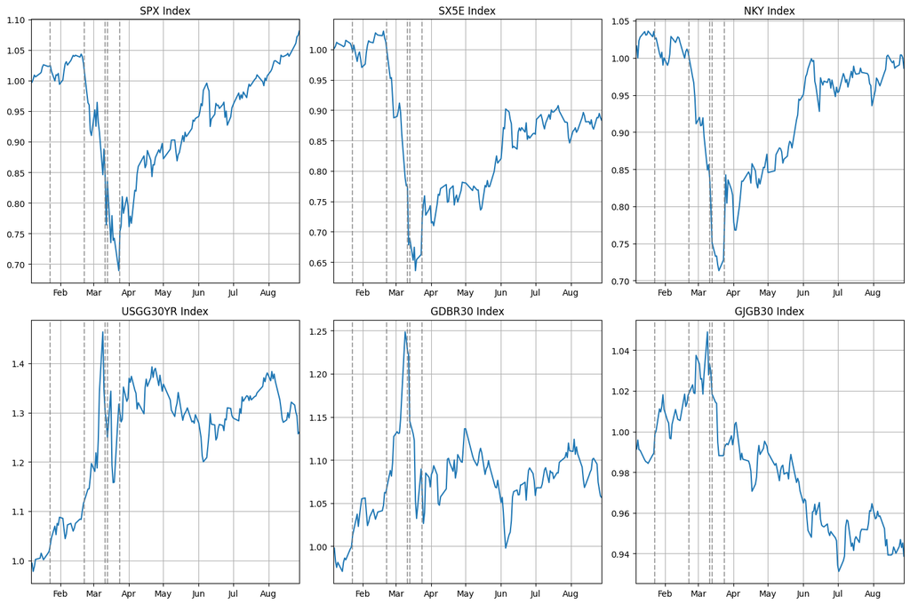

```python
# Calculate percentage returns
returns = calc_pct_returns(DATA_DIR)

# Create a figure similar to Figure 1
fig, axes = plt.subplots(nrows=2, ncols=3, figsize=(15, 10))
axes = axes.flatten()

for i, col in enumerate(returns.columns):
    axes[i].plot(returns.index, returns[col], label=col)
    axes[i].set_title(col)
    axes[i].set_xlim([returns.index[0], returns.index[-1]])

    # Generate ticks at the start of each month
    xticks = pd.date_range(start=returns.index[0], end=returns.index[-1], freq="MS")
    axes[i].set_xticks(xticks)
    axes[i].set_xticklabels([x.strftime("%b") for x in xticks])
    axes[i].grid()

    # Add vertical lines for key events
    key_dates = [
        pd.Timestamp('2020-01-23'),  # Wuhan lockdown
        pd.Timestamp('2020-02-22'),  # Italy quarantine
        pd.Timestamp('2020-03-11'),  # US travel ban
        pd.Timestamp('2020-03-13'),  # US emergency declaration
        pd.Timestamp('2020-03-24')   # US stimulus news
    ]

    for date in key_dates:
        if date >= returns.index[0] and date <= returns.index[-1]:
            axes[i].axvline(x=date, color='gray', linestyle='--', alpha=0.7)

plt.tight_layout()
plt.show()
```

## 5. Table 1 Replication: Predictive Regressions of Dividend Growth on Dividend Yields

Table 1 in the paper shows results from predictive regressions similar to equation (3), where realized dividend growth is regressed onto the ex-ante two-year dividend yield. This is a key part of the methodology used to forecast dividend growth from dividend futures.

```python
import pandas as pd

# Load the regression results
df = pd.read_csv('../_output/tables/table1_results.csv')

# Extract the key values
try:
    # Find the coefficient on equity yield (e_it^(2))
    equity_yield_coef = df.loc[0, '$e_{it}^{(2)}$'] if '$e_{it}^{(2)}$' in df.columns else "Not found"

    # Get the R-squared value
    r_squared = df.loc[0, '$R^2$'] if '$R^2$' in df.columns else "Not found"

    # Get number of observations
    n_obs = df.loc[0, '\# Obs'] if '\# Obs' in df.columns else "Not found"

    # Print just the key findings
    print("Key regression findings:")
    print(f"- Coefficient on equity yield: {equity_yield_coef}")
    print(f"- R²: {r_squared}")
    print(f"- Number of observations: {n_obs}")
    print("This regression relates dividend yields to future dividend growth, which is essential for forecasting growth expectations")

except Exception as e:
    print(f"Error extracting values: {e}")
    print("Column names in the dataframe:", df.columns.tolist())
```

```
Key regression findings:
- Coefficient on equity yield: -23.25
(18.79)
- R²: 0.04
- Number of observations: 79
This regression relates dividend yields to future dividend growth, which is essential for forecasting growth expectations
```

The regression takes the form: $$\Delta_1 D_{i,t} = \beta_0 + \beta_1 e_{it}^{(2)} + \varepsilon_{t+4}$$

Where:

- $\Delta_1 D_{i,t}$ is the dividend growth rate
- $e_{it}^{(2)}$ is the 2-year equity yield
- The coefficient on equity yield

This coefficient is then used to forecast dividend growth during the COVID-19 period.

## 6. Figure 5 Replication: Expected Dividend and GDP Growth from Dividend Futures

### Panel A: Expected Dividend Growth

```python
def load_replication_data():
    """Load the processed data needed for replicating Table 1 and Figure 5"""
    try:
        # Load the quarterly data for Table 1 regression
        quarterly_path = Path(DATA_DIR) / "clean" / "merged_dividend_data_quarterly.parquet"
        quarterly_df = pd.read_parquet(quarterly_path)

        # Load the forecast data for Figure 5
        forecast_path = Path(OUTPUT_DIR) / "figures" / "forecast_paper_dividend_growth.parquet"
        forecasts_df = pd.read_parquet(forecast_path)

        print("Successfully loaded data files for replication")
        return quarterly_df, forecasts_df
    except FileNotFoundError as e:
        print(f"Error: {e}")
        print("Make sure you've run the data processing scripts first")
        return None, None

quarterly_data, forecast_data = load_replication_data()


print("\nForecast Data Sample (for Figure 5):")
display(forecast_data.head())
```

```
Successfully loaded data files for replication

Forecast Data Sample (for Figure 5):
```

| Date | US_Expected_Div_Growth | EU_Expected_Div_Growth | JP_Expected_Div_Growth |
| --- | --- | --- | --- |
| 2020-01-02 | 5.067738 | 4.504820 | 4.688034 |
| 2020-01-03 | 5.051513 | 4.448751 | 4.688034 |
| 2020-01-06 | 5.060183 | 4.432174 | 4.625314 |
| 2020-01-07 | 5.007646 | 4.450866 | 4.673371 |
| 2020-01-08 | 4.956726 | 4.450959 | 4.656108 |

```python
# Extract the dividend growth expectations from the forecast data

# Define key dates mentioned in the paper
key_dates = [
    '2020-01-01',  # January 1
    '2020-01-23',  # Lockdown of Wuhan
    '2020-02-22',  # Italy quarantine announcement
    '2020-03-11',  # US travel ban from EU
    '2020-03-13',  # US national emergency declaration
    '2020-03-24',  # US fiscal stimulus news
]

# Get data for Panel A - Expected Dividend Growth
panel_a_data = forecast_data.copy()

# Make sure column names match our expected format
region_mapping = {
    'US_Expected_Div_Growth': 'US_Dividend_Growth',
    'EU_Expected_Div_Growth': 'EU_Dividend_Growth',
    'JP_Expected_Div_Growth': 'JP_Dividend_Growth'
}

# Rename columns if needed
panel_a_data = panel_a_data.rename(columns=region_mapping)

# Get values at key dates for annotations
key_dates_df = panel_a_data.reindex(pd.to_datetime(key_dates), method='nearest')

print("Expected Dividend Growth at Key Dates:")
display(key_dates_df)
```

```
Expected Dividend Growth at Key Dates:
```

|  | US_Dividend_Growth | EU_Dividend_Growth | JP_Dividend_Growth |
| --- | --- | --- | --- |
| 2020-01-01 | 5.067738 | 4.504820 | 4.688034 |
| 2020-01-23 | 5.066280 | 4.376662 | 4.608995 |
| 2020-02-22 | 4.958677 | 4.342802 | 4.553511 |
| 2020-03-11 | 3.862063 | 1.863093 | 3.659365 |
| 2020-03-13 | 2.915199 | 0.555749 | 2.858045 |
| 2020-03-24 | -0.720023 | -3.967459 | 0.022973 |

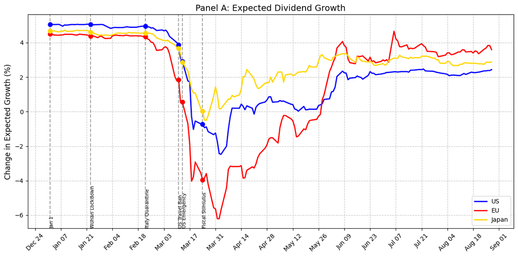

```python
fig, ax = plt.subplots(figsize=(12, 6))

# Plot dividend growth for each region
ax.plot(panel_a_data.index, panel_a_data['US_Dividend_Growth'],
        label='US', color='blue', linewidth=2)
ax.plot(panel_a_data.index, panel_a_data['EU_Dividend_Growth'],
        label='EU', color='red', linewidth=2)
ax.plot(panel_a_data.index, panel_a_data['JP_Dividend_Growth'],
        label='Japan', color='gold', linewidth=2)

# Add markers for key dates
for region, color in [('US_Dividend_Growth', 'blue'),
                      ('EU_Dividend_Growth', 'red'),
                      ('JP_Dividend_Growth', 'gold')]:
    ax.scatter(key_dates_df.index, key_dates_df[region],
              color=color, s=50, zorder=5)

# Add vertical lines for key events
event_labels = [
    'Jan 1',
    'Wuhan Lockdown',
    'Italy Quarantine',
    'US Travel Ban',
    'US Emergency',
    'Fiscal Stimulus'
]

for date, label in zip(key_dates, event_labels):
    ax.axvline(x=pd.to_datetime(date), color='gray', linestyle='--', alpha=0.7)
    ax.text(pd.to_datetime(date), ax.get_ylim()[0], label,
            rotation=90, verticalalignment='bottom', fontsize=8)

# Configure axis formatting
ax.xaxis.set_major_formatter(mdates.DateFormatter('%b %d'))
ax.xaxis.set_major_locator(mdates.WeekdayLocator(interval=2))
plt.xticks(rotation=45)

# Add title and labels
ax.set_title('Panel A: Expected Dividend Growth', fontsize=14)
ax.set_ylabel('Change in Expected Growth (%)', fontsize=12)
ax.grid(True, linestyle='--', alpha=0.7)
ax.legend()

plt.tight_layout()
plt.show()
```

### Panel B: Expected GDP Growth

```python
# Convert dividend growth expectations to GDP growth expectations

def convert_div_to_gdp_growth(dividend_growth, region):
    """
    Convert dividend growth to GDP growth using coefficients from the paper
    """
    # Coefficients from the paper
    conversion_factors = {
        'US': 0.22,  # This maps div growth to GDP growth in the US
        'EU': 0.22,  # Using the same factor for EU as mentioned in paper
        'JP': 0.22   # Using the same factor for Japan
    }

    return dividend_growth * conversion_factors[region]

# Create DataFrame for Panel B
panel_b_data = pd.DataFrame(index=panel_a_data.index)

# Convert dividend growth to GDP growth
for region in ['US', 'EU', 'JP']:
    div_col = f"{region}_Dividend_Growth"
    if div_col in panel_a_data.columns:
        panel_b_data[f"{region}_GDP_Growth"] = convert_div_to_gdp_growth(
            panel_a_data[div_col], region)

# Get values at key dates for annotations
key_dates_gdp_df = panel_b_data.reindex(pd.to_datetime(key_dates), method='nearest')

print("Expected GDP Growth at Key Dates:")
display(key_dates_gdp_df)
```

```
Expected GDP Growth at Key Dates:
```

|  | US_GDP_Growth | EU_GDP_Growth | JP_GDP_Growth |
| --- | --- | --- | --- |
| 2020-01-01 | 1.114902 | 0.991060 | 1.031367 |
| 2020-01-23 | 1.114582 | 0.962866 | 1.013979 |
| 2020-02-22 | 1.090909 | 0.955416 | 1.001772 |
| 2020-03-11 | 0.849654 | 0.409880 | 0.805060 |
| 2020-03-13 | 0.641344 | 0.122265 | 0.628770 |
| 2020-03-24 | -0.158405 | -0.872841 | 0.005054 |

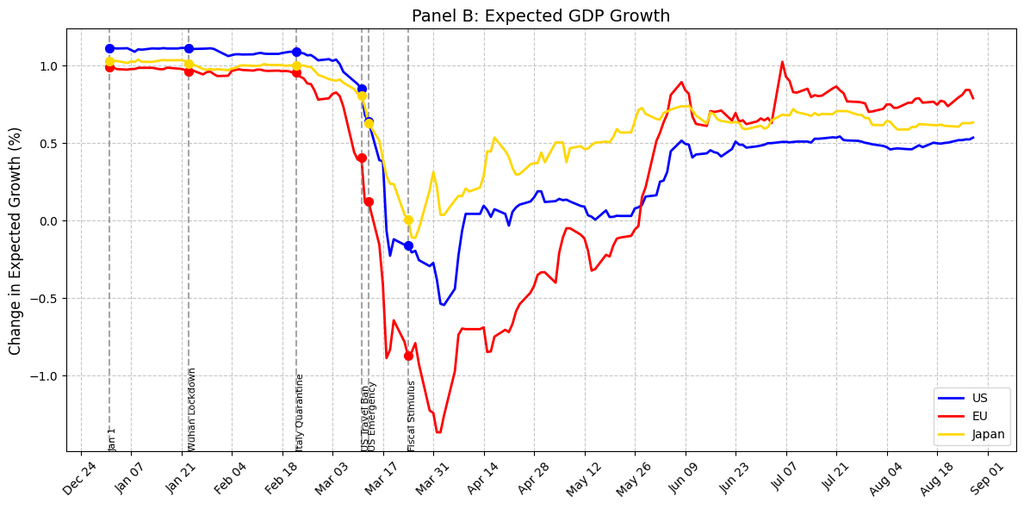

```python
fig, ax = plt.subplots(figsize=(12, 6))

# Plot GDP growth for each region
ax.plot(panel_b_data.index, panel_b_data['US_GDP_Growth'],
        label='US', color='blue', linewidth=2)
ax.plot(panel_b_data.index, panel_b_data['EU_GDP_Growth'],
        label='EU', color='red', linewidth=2)
ax.plot(panel_b_data.index, panel_b_data['JP_GDP_Growth'],
        label='Japan', color='gold', linewidth=2)

# Add markers for key dates
for region, color in [('US_GDP_Growth', 'blue'),
                      ('EU_GDP_Growth', 'red'),
                      ('JP_GDP_Growth', 'gold')]:
    ax.scatter(key_dates_gdp_df.index, key_dates_gdp_df[region],
              color=color, s=50, zorder=5)

# Add vertical lines for key events
for date, label in zip(key_dates, event_labels):
    ax.axvline(x=pd.to_datetime(date), color='gray', linestyle='--', alpha=0.7)
    ax.text(pd.to_datetime(date), ax.get_ylim()[0], label,
            rotation=90, verticalalignment='bottom', fontsize=8)

# Configure axis formatting
ax.xaxis.set_major_formatter(mdates.DateFormatter('%b %d'))
ax.xaxis.set_major_locator(mdates.WeekdayLocator(interval=2))
plt.xticks(rotation=45)

# Add title and labels
ax.set_title('Panel B: Expected GDP Growth', fontsize=14)
ax.set_ylabel('Change in Expected Growth (%)', fontsize=12)
ax.grid(True, linestyle='--', alpha=0.7)
ax.legend()

plt.tight_layout()
plt.show()
```

## 7. Challenges and Insights

During this replication project, we encountered several challenges:

1. **Data Availability**: Finding dividend futures data was challenging, as this data is not readily available in many public datasets.
2. **Bloomberg Access**: Access to Bloomberg terminals was limited, so we had to create a fallback mechanism using CSV files.
3. **Methodology Details**: Some methodological details in the paper were described briefly, requiring careful reading and interpretation.

## 8. Conclusion

This project demonstrates the value of financial markets as a source of forward-looking information during crisis periods, and how dividend futures can be used to extract growth expectations.